# Homework 3 - Smoothers, GAMs, CART, Trees, SVC

Author

Kellie Keeling

Published

08-15-2023-19:32PM

## Load Packages

```r
library(gridExtra) #v2.3 grid.arrange()
library(vip) #v0.4.0 vip() (variable importance)
library(ggcorrplot) #v0.1.4
library(ISLR) #v1.4 College dataset
library(splines) #v4.2.3 bs, ns() - note: part of base R
library(mgcv) #v1.9-0 gam() - different from book gam()
library(mgcViz) #v0.1.9 getViz() plot for gams
library(ranger) #v 0.15.1 rand_forest() #bagging and random forest
library(xgboost) #v1.7.5.1 boost_tree()
library(kernlab) #v0.9-31 svm_poly() and svm_rbf()
library(janitor) #v2.1.0 clean_names()
library(knitr) #v1.42 kable() #formatted tables - uses digits (keep <=1.42 quarto plotly error)
library(tidymodels)
library(ggplot2)
library(patchwork)
  #library(parsnip) #v1.0.3 decision_tree(), gen_additive_mod(), set_engine(), set_mode(), fit(), predict()
  #library(yardstick) #v1.1.0 metrics(), rac_auc(), roc_curve(), metric_set(), conf_matrix()
  #library(dplyr) #v1.0.10 %>%, select(), select_if(), filter(), mutate(), group_by(),
    #summarize(), tibble()
  #library(ggplot2) #v3.3.0 ggplot()
  #library(broom) #v1.0.2 for tidy(), augment(), glance()
  #library(rsample) #v1.1.1 initial_split()
library(readr) #v2.1.3 read_csv()
theme_set(theme_bw())
```

## Homework Guidelines

This assignment is for you to complete individually. For individual work, you may work together on homework so long as each person is using their own technology to solve problems and turning in their individual work. Looking over someone’s shoulder or watching as they do work, no matter how much you feel like you are participating, is not working together. Turning in individual work done by someone else is academic dishonesty and can result in penalties ranging from zero points on the assignment to an “F” in the class and dismissal from the class.

## Use CART and GAMs to predict the out of state tuition

This question uses the College data set for the ISLR package and is modified from Question 10 (a) from Chapter 7.

## 1 Create training/test data.

```r
set.seed(157)

# Read in the College dataset
df_col <- College

# Split the data into Training and Testing (65% and 35%, respectively)
col_split <- initial_split(df_col, prop = .60)
col_train <- rsample::training(col_split)
col_test <- rsample::testing(col_split)

# View Column names
names(df_col)
```

```
 [1] "Private"     "Apps"        "Accept"      "Enroll"      "Top10perc"
 [6] "Top25perc"   "F.Undergrad" "P.Undergrad" "Outstate"    "Room.Board"
[11] "Books"       "Personal"    "PhD"         "Terminal"    "S.F.Ratio"
[16] "perc.alumni" "Expend"      "Grad.Rate"
```

Use a recipe to create datasets that have their predictor variables converted so nominal variables become dummys and all predictors are normalized. Use the recipe on the data so you end up with a full/original normalized dataset, a training normalized dataset, and a testing normalized dataset.

```r
# Create a recipe to preprocess the data
col_recipe <- recipe(Outstate ~ ., data = df_col) %>%
  step_dummy(all_nominal(), one_hot = TRUE) %>%
  step_normalize(all_numeric_predictors()) %>%
  prep()

# Apply the recipe to the training and testing sets
col_train_baked <- bake(col_recipe, new_data = col_train)
col_test_baked <- bake(col_recipe, new_data = col_test)
col_full_baked <- bake(col_recipe, new_data = df_col)
```

View the `head()` of the full normalized dataset with `kable()` so all the columns show in your .html output.

```r
head(col_full_baked) %>%
  kable()
```

| Apps | Accept | Enroll | Top10perc | Top25perc | F.Undergrad | P.Undergrad | Room.Board | Books | Personal | PhD | Terminal | S.F.Ratio | perc.alumni | Expend | Grad.Rate | Outstate | Private_No | Private_Yes |
| --- | --- | --- | --- | --- | --- | --- | --- | --- | --- | --- | --- | --- | --- | --- | --- | --- | --- | --- |
| -0.3466585 | -0.3209987 | -0.0634680 | -0.2584163 | -0.1917039 | -0.1680076 | -0.2090725 | -0.9642836 | -0.6019244 | 1.2692276 | -0.1629230 | -0.1156542 | 1.0131234 | -0.8670157 | -0.5015870 | -0.3180471 | 7440 | -0.6121587 | 0.6121587 |
| -0.2107483 | -0.0386781 | -0.2883984 | -0.6552335 | -1.3530399 | -0.2096534 | 0.2441498 | 1.9079789 | 1.2150971 | 0.2353633 | -2.6739232 | -3.3760014 | -0.4773970 | -0.5442217 | 0.1660029 | -0.5509070 | 12280 | -0.6121587 | 0.6121587 |
| -0.4066037 | -0.3760757 | -0.4778135 | -0.3151045 | -0.2926897 | -0.5492116 | -0.4967701 | -0.5539604 | -0.9047614 | -0.2594146 | -1.2040694 | -0.9307410 | -0.3005556 | 0.5855576 | -0.1771758 | -0.6673369 | 11250 | -0.6121587 | 0.6121587 |
| -0.6678304 | -0.6812431 | -0.6919818 | 1.8390460 | 1.6765321 | -0.6576558 | -0.5204164 | 0.9961495 | -0.6019244 | -0.6877298 | 1.1844430 | 1.1748999 | -1.6142346 | 1.1504472 | 1.7916974 | -0.3762621 | 12960 | -0.6121587 | 0.6121587 |
| -0.7257086 | -0.7640625 | -0.7802320 | -0.6552335 | -0.5956469 | -0.7114656 | 0.0089997 | -0.2165835 | 1.5179340 | 0.2353633 | 0.2045405 | -0.5231976 | -0.5531862 | -1.6740009 | 0.2416478 | -2.9377211 | 7560 | -0.6121587 | 0.6121587 |
| -0.6239051 | -0.6282059 | -0.6693811 | 0.5919062 | 0.3132247 | -0.6230197 | -0.5348670 | -0.9323696 | -0.2990875 | -0.9831196 | -0.3466547 | -0.4552737 | -1.1847626 | -0.9477142 | 0.0127981 | -0.6091220 | 13500 | -0.6121587 | 0.6121587 |

## 2 Regression Tree

### 2a. Define and Fit a Regression Tree

Using out-of-state tuition as the response and the other variables as the predictors, use a regression tree to perform variable selection on the training set. We will do this by examining the most important variables identified in an initial model.

Define Model Specifications and fit the model to the training data

```r
#Define the model specification
tree_reg_spec <- decision_tree() %>%
                    set_engine("rpart") %>%
                    set_mode("regression")

#Fit the model
tree_col_fit <- tree_reg_spec %>%
  fit(Outstate ~ ., data = col_train_baked)

tree_col_fit
```

```
parsnip model object

n= 466

node), split, n, deviance, yval
      * denotes terminal node

 1) root 466 7787426000 10384.790
   2) Expend< -0.04398341 295 1943346000  8315.231
     4) Private_No>=0.509651 107  372418100  6364.364
       8) Expend< -0.71052 42   79835040  5300.952 *
       9) Expend>=-0.71052 65  214398200  7051.492 *
     5) Private_No< 0.509651 188  931924500  9425.564
      10) Room.Board< -0.5585195 80  308998200  7936.938
        20) perc.alumni< -0.7459679 25   30901820  6458.600 *
        21) perc.alumni>=-0.7459679 55  198624300  8608.909 *
      11) Room.Board>=-0.5585195 108  314326600 10528.250 *
   3) Expend>=-0.04398341 171 2400825000 13955.090
     6) Private_No>=0.509651 25  174252400  8821.040 *
     7) Private_No< 0.509651 146 1454773000 14834.210
      14) Expend< 0.6458212 85  497167800 13194.360
        28) Terminal< -0.1496162 17   72466190 10390.410 *
        29) Terminal>=-0.1496162 68  257630800 13895.350 *
      15) Expend>=0.6458212 61  410528100 17119.250
        30) Grad.Rate< 0.1185653 11  127511000 14310.910 *
        31) Grad.Rate>=0.1185653 50  177176900 17737.080 *
```

### 2b. View the variable importance

Create the vip plot so that it shows all the variables by using the second parameter to indicate the number of variables/features to show `vip(model object, num_features)`.

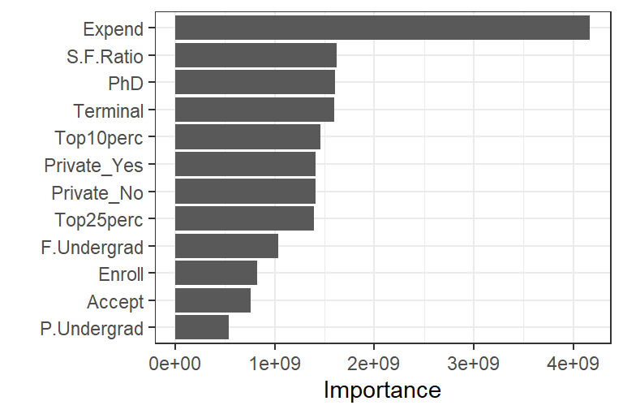

```r
vip(tree_col_fit, num_features = 12)
```

Moving forward, let’s keep the top 12 important predictors.

What predictors will you keep? We will keep (in order of importance): - Expend - S.F.Ratio - PhD - Terminal - Top10perc - Private_Yes - Private_No - Top25perc - F.Undergrad - Enroll - Accept - P.Undergrad

### 2c. Find the error measures on the test data.

Store the predictions on the Test data in a table and find the metrics (RMSE, MAE, and R-Squared). Store these in a `results` table and view the metrics with 2 decimal places.

```r
pred_tree_col_fit <- tree_col_fit %>%
  augment(col_test_baked)


my_metrics = yardstick::metric_set(yardstick::rmse,
                                         yardstick::mae,
                                         yardstick::rsq)

curr_metrics <- pred_tree_col_fit %>%
                    my_metrics(truth=Outstate, estimate=.pred)

results <- tibble(model = 'Regression Tree',
                  rmse = curr_metrics[[1,3]],
                  mae = curr_metrics[[2,3]],
                  r_squared = curr_metrics[[3,3]])

results%>%
  kable(digits = 2)
```

| model | rmse | mae | r_squared |
| --- | --- | --- | --- |
| Regression Tree | 2064.44 | 1629.75 | 0.72 |

### 2d. Display a plot of the actual vs predicted values for the test data.

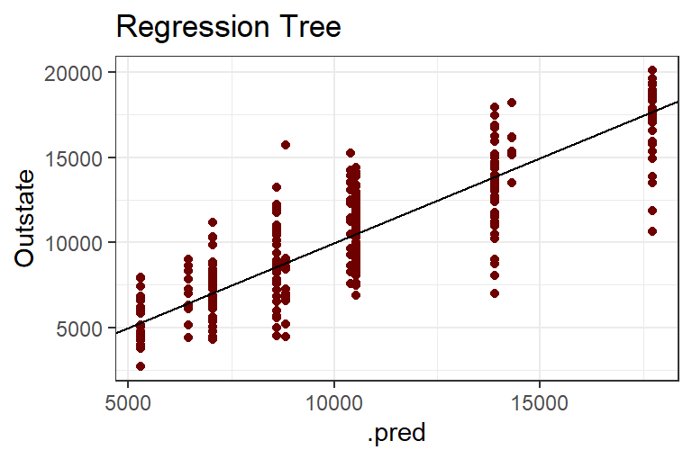

```r
ggplot(data = pred_tree_col_fit,
       aes(x = .pred, y = Outstate)) +
  geom_point(col = "#6e0000") +
  geom_abline(slope = 1) +
  ggtitle("Regression Tree")
```

## 3 GAM models

### 3a. Fit a full GAM on the training data

Fit a GAM using out-of-state tuition as the response and the variables/features selected in the previous step (from the Regression Tree) as the predictors using the normalized training data.

For the full GAM model, use cubic smoothers for all the predictors except Private (which is qualitative). We do want to use the Private variable, but note it now has a new name in the normalized dataset.

View the summary of the results.

```r
#Define the model specification
gam_spec <- gen_additive_mod() %>%
              set_engine("mgcv", importance = "impurity") %>%
              set_mode("regression")
#Fit the model
gam_col_fit <- gam_spec %>%
  fit(Outstate ~ s(Expend, bs = "cr") + s(S.F.Ratio, bs = "cr") +
        s(PhD, bs = "cr") + s(Terminal, bs = "cr") + s(Top10perc, bs = "cr") +
        s(Top25perc, bs = "cr") + s(F.Undergrad, bs = "cr") +
        s(Enroll, bs = "cr") + s(Accept, bs = "cr") + s(P.Undergrad, bs = "cr")+
        Private_Yes + Private_No,
      data = col_train_baked)

summary(gam_col_fit$fit)
```

```
Family: gaussian
Link function: identity

Formula:
Outstate ~ s(Expend, bs = "cr") + s(S.F.Ratio, bs = "cr") + s(PhD,
    bs = "cr") + s(Terminal, bs = "cr") + s(Top10perc, bs = "cr") +
    s(Top25perc, bs = "cr") + s(F.Undergrad, bs = "cr") + s(Enroll,
    bs = "cr") + s(Accept, bs = "cr") + s(P.Undergrad, bs = "cr") +
    Private_Yes + Private_No

Parametric coefficients:
            Estimate Std. Error t value Pr(>|t|)
(Intercept) 10415.91      85.39 121.984   <2e-16 ***
Private_Yes   665.72      71.42   9.321   <2e-16 ***
Private_No   -665.72      71.42  -9.321   <2e-16 ***
---
Signif. codes:  0 '***' 0.001 '**' 0.01 '*' 0.05 '.' 0.1 ' ' 1

Approximate significance of smooth terms:
                 edf Ref.df      F  p-value
s(Expend)      2.903  3.435 34.790  < 2e-16 ***
s(S.F.Ratio)   4.589  5.663  3.226 0.005235 **
s(PhD)         7.125  8.147  2.523 0.008682 **
s(Terminal)    6.913  7.952  3.326 0.001110 **
s(Top10perc)   1.000  1.000  4.497 0.034541 *
s(Top25perc)   1.098  1.189  2.635 0.093512 .
s(F.Undergrad) 5.565  6.184  3.838 0.000829 ***
s(Enroll)      4.515  5.201  5.477 5.61e-05 ***
s(Accept)      3.297  3.814 17.915  < 2e-16 ***
s(P.Undergrad) 1.000  1.001  0.322 0.570343
---
Signif. codes:  0 '***' 0.001 '**' 0.01 '*' 0.05 '.' 0.1 ' ' 1

Rank: 92/93
R-sq.(adj) =  0.797   Deviance explained = 81.4%
GCV = 3.711e+06  Scale est. = 3.3924e+06  n = 466
```

What is the Training data R-squared? The R-squared value for the training data is 79.7%

### 3b. Prune the GAMs model

For the second GAMS model, continue using the training data and remove the nonsignificant predictors (use alpha = .05) one by one (remove the largest p-value each time) until you have your final second GAMs model. View the final model summary.

```r
#Prune the model
gam_col_fit2 <- gam_spec %>%
  fit(Outstate ~ s(Expend, bs = "cr") + s(S.F.Ratio, bs = "cr") +
        s(PhD, bs = "cr") + s(Terminal, bs = "cr") + s(F.Undergrad, bs = "cr")+
        s(Enroll, bs = "cr") + s(Accept, bs = "cr")+ Private_Yes + Private_No,
      data = col_train_baked)

summary(gam_col_fit2$fit)
```

```
Family: gaussian
Link function: identity

Formula:
Outstate ~ s(Expend, bs = "cr") + s(S.F.Ratio, bs = "cr") + s(PhD,
    bs = "cr") + s(Terminal, bs = "cr") + s(F.Undergrad, bs = "cr") +
    s(Enroll, bs = "cr") + s(Accept, bs = "cr") + Private_Yes +
    Private_No

Parametric coefficients:
            Estimate Std. Error t value Pr(>|t|)
(Intercept) 10416.52      85.55 121.757   <2e-16 ***
Private_Yes   678.74      70.39   9.642   <2e-16 ***
Private_No   -678.74      70.39  -9.642   <2e-16 ***
---
Signif. codes:  0 '***' 0.001 '**' 0.01 '*' 0.05 '.' 0.1 ' ' 1

Approximate significance of smooth terms:
                 edf Ref.df      F  p-value
s(Expend)      3.112  3.663 43.038  < 2e-16 ***
s(S.F.Ratio)   4.492  5.557  2.849 0.012431 *
s(PhD)         7.326  8.296  2.754 0.003800 **
s(Terminal)    6.805  7.864  3.041 0.002699 **
s(F.Undergrad) 5.607  6.229  3.892 0.000702 ***
s(Enroll)      4.593  5.283  4.734 0.000255 ***
s(Accept)      3.262  3.772 17.444  < 2e-16 ***
---
Signif. codes:  0 '***' 0.001 '**' 0.01 '*' 0.05 '.' 0.1 ' ' 1

Rank: 65/66
R-sq.(adj) =  0.797   Deviance explained = 81.2%
GCV = 3.7011e+06  Scale est. = 3.4056e+06  n = 466
```

Explain your findings from this final GAMS model 2. What is the R-sq?

### 3c. Evaluate the GAM model 2 obtained on the test set

Find the predictions on the test dataset and store them in a table. Calculate the RMSE, MAE, and R-Squared and store them in your results table with the regression tree metrics. View the metrics with 2 decimal places.

```r
pred_gam_col_fit <- gam_col_fit2 %>%
  augment(col_test_baked)

curr_metrics <- pred_gam_col_fit %>%
                    my_metrics(truth=Outstate, estimate=.pred)

new_results <- tibble(model = 'pruned GAM',
                  rmse = curr_metrics[[1,3]],
                  mae = curr_metrics[[2,3]],
                  r_squared = curr_metrics[[3,3]])

results <- bind_rows(results, new_results)

results %>%
  kable(digits = 2)
```

| model | rmse | mae | r_squared |
| --- | --- | --- | --- |
| Regression Tree | 2064.44 | 1629.75 | 0.72 |
| pruned GAM | 2018.18 | 1559.32 | 0.74 |

How do the metrics metrics compare to the Regression Tree? The Pruned GAMs Model performed slightly better than the regression tree because it has a slightly higher R-squared value. It also has both a lower Mean Absolute Error and Root Mean Square Error which signifies that the Pruned GAMs model has a lower average difference between its predicted values and the actual values, rather than the Regression Tree which has more error.

### 3d. Look at the gam.check output for GAM 2.

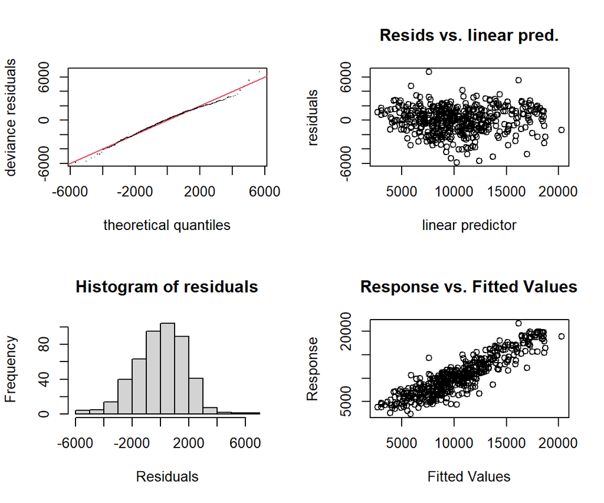

```
Method: GCV   Optimizer: magic
Smoothing parameter selection converged after 7 iterations.
The RMS GCV score gradient at convergence was 7.313623 .
The Hessian was positive definite.
Model rank =  65 / 66

Basis dimension (k) checking results. Low p-value (k-index<1) may
indicate that k is too low, especially if edf is close to k'.

                 k'  edf k-index p-value
s(Expend)      9.00 3.11    1.02    0.59
s(S.F.Ratio)   9.00 4.49    0.99    0.35
s(PhD)         9.00 7.33    1.00    0.49
s(Terminal)    9.00 6.80    1.08    0.94
s(F.Undergrad) 9.00 5.61    0.96    0.21
s(Enroll)      9.00 4.59    1.01    0.56
s(Accept)      9.00 3.26    1.02    0.68
```

```r
gam.check(gam_col_fit2$fit)
```

Do you see any issues based on the basis dimension (k) check? I do not see any issues based off of the basic dimension (k) check

### 3e. View the GAMs predictors graphs with getViz

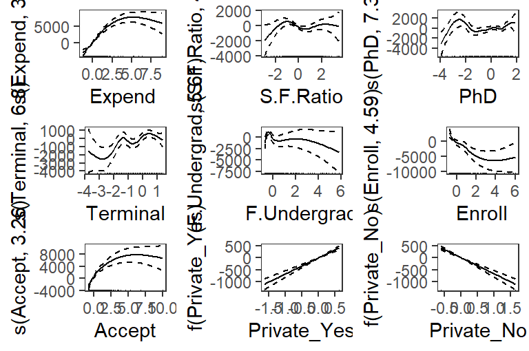

```r
gam_2_fit_viz <- getViz(gam_col_fit2$fit)

print(plot(gam_2_fit_viz, allTerms=TRUE), pages = 1)
```

### 3f. For which variables, if any, is there strong evidence of a non-linear relationship with the response?

There is strong evidence of non linear relationships with Out-of-State tuition for the variables Expend, S.F.Ratio, PhD, Terminal, F.Undergrad, and Accept

### 3g. Create a GAM 3 model with fewer smoothing terms.

Add a new model by changing the GAM 2 model so that only those predictors you identified above having non-linear relationships still have smoothing terms. The rest just keep in the model without smoothing.

```r
#Prune the model with less smoothing terms
gam_col_fit3 <- gam_spec %>%
  fit(Outstate ~ s(Expend, bs = "cr") + s(S.F.Ratio, bs = "cr") +
        s(PhD, bs = "cr") + s(Terminal, bs = "cr") +
        s(F.Undergrad, bs = "cr") + s(Accept, bs = "cr") +
        Enroll + Private_Yes + Private_No,
      data = col_train_baked)

summary(gam_col_fit3$fit)
```

```
Family: gaussian
Link function: identity

Formula:
Outstate ~ s(Expend, bs = "cr") + s(S.F.Ratio, bs = "cr") + s(PhD,
    bs = "cr") + s(Terminal, bs = "cr") + s(F.Undergrad, bs = "cr") +
    s(Accept, bs = "cr") + Enroll + Private_Yes + Private_No

Parametric coefficients:
            Estimate Std. Error t value Pr(>|t|)
(Intercept) 10437.75      87.54 119.236   <2e-16 ***
Enroll      -1200.88     416.19  -2.885   0.0041 **
Private_Yes   681.25      71.26   9.560   <2e-16 ***
Private_No   -681.25      71.26  -9.560   <2e-16 ***
---
Signif. codes:  0 '***' 0.001 '**' 0.01 '*' 0.05 '.' 0.1 ' ' 1

Approximate significance of smooth terms:
                 edf Ref.df      F  p-value
s(Expend)      3.045  3.592 40.093  < 2e-16 ***
s(S.F.Ratio)   4.489  5.555  3.039  0.00826 **
s(PhD)         7.281  8.265  2.822  0.00324 **
s(Terminal)    6.756  7.824  3.018  0.00299 **
s(F.Undergrad) 5.424  6.021  5.778 8.21e-06 ***
s(Accept)      2.890  3.350 15.283  < 2e-16 ***
---
Signif. codes:  0 '***' 0.001 '**' 0.01 '*' 0.05 '.' 0.1 ' ' 1

Rank: 57/58
R-sq.(adj) =  0.789   Deviance explained = 80.3%
GCV = 3.8094e+06  Scale est. = 3.5406e+06  n = 466
```

## 4 Compare the GAMs and Tree models

### 4a. Evaluate the model obtained on the test set

Find the predictions on the test dataset for GAM model 3 and calculate the RMSE, MAE, and R-Squared. Add these to the results table and view the results with 2 decimal places.

```r
pred_gam_col_fit_final <- gam_col_fit3 %>%
  augment(col_test_baked)

curr_metrics <- pred_gam_col_fit_final %>%
                    my_metrics(truth=Outstate, estimate=.pred)

new_results <- tibble(model = 'pruned GAM 3',
                  rmse = curr_metrics[[1,3]],
                  mae = curr_metrics[[2,3]],
                  r_squared = curr_metrics[[3,3]])

results <- bind_rows(results, new_results)

results %>%
  kable(digits = 2)
```

| model | rmse | mae | r_squared |
| --- | --- | --- | --- |
| Regression Tree | 2064.44 | 1629.75 | 0.72 |
| pruned GAM | 2018.18 | 1559.32 | 0.74 |
| pruned GAM 3 | 1989.89 | 1533.92 | 0.75 |

### 4b. Use anova and AIC to compare your GAM 2 and GAM 3 Model

```r
out <- anova(gam_col_fit2$fit, gam_col_fit3$fit,
             test="F")

out
```

```
Analysis of Deviance Table

Model 1: Outstate ~ s(Expend, bs = "cr") + s(S.F.Ratio, bs = "cr") + s(PhD,
    bs = "cr") + s(Terminal, bs = "cr") + s(F.Undergrad, bs = "cr") +
    s(Enroll, bs = "cr") + s(Accept, bs = "cr") + Private_Yes +
    Private_No
Model 2: Outstate ~ s(Expend, bs = "cr") + s(S.F.Ratio, bs = "cr") + s(PhD,
    bs = "cr") + s(Terminal, bs = "cr") + s(F.Undergrad, bs = "cr") +
    s(Accept, bs = "cr") + Enroll + Private_Yes + Private_No
  Resid. Df Resid. Dev      Df  Deviance      F    Pr(>F)
1    423.33 1460352107
2    428.39 1533473154 -5.0585 -73121048 4.2444 0.0008453 ***
---
Signif. codes:  0 '***' 0.001 '**' 0.01 '*' 0.05 '.' 0.1 ' ' 1
```

### 4c. Interpret the results.

What did you learn from these results? Which GAM model should we keep?

### 4d Display a plot of the actual vs predicted values for the test data.

Display the predicted values for both the regression tree and the final chosen GAMS model in the same scatterplot.

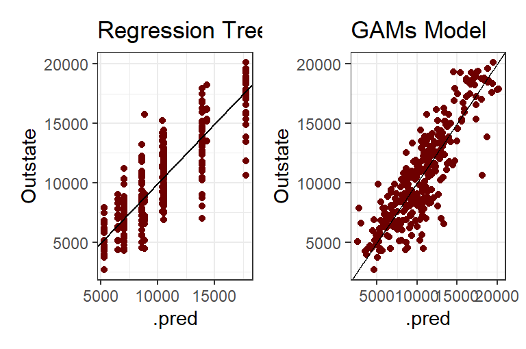

```r
# Create scatterplot for Regression Tree
plot_tree <- ggplot(data = pred_tree_col_fit,
       aes(x = .pred, y = Outstate)) +
  geom_point(col = "#6e0000") +
  geom_abline(slope = 1) +
  ggtitle("Regression Tree")

# Create scatterplot for GAMs model
plot_gam <- ggplot(data = pred_gam_col_fit_final,
       aes(x = .pred, y = Outstate)) +
  geom_point(col = "#6e0000") +
  geom_abline(slope = 1) +
  ggtitle("GAMs Model")

# Combine plots using patchwork
combined_plots <- plot_tree + plot_gam

# Display the combined plots
print(combined_plots)
```

### 4e. Compare your regression tree model and your chosen GAMs model

Compare based on the test RMSE, MAE, and R-Squared, and your actual versus predicted plot. Which model would you use moving forward to predict out of state students? Describe this final model (what is the formula?).

I believe that the Final GAMs model should be used going forward because it has less RMSE and MAE which highlights the model’s superiority to predict Out of State Tuition with less error. It also has a higher R-squared value which means it does a better job of explaining the variance within the dataset. Lastly, When looking at the plots, We can see a positive linear trend or pattern within the final GAMS model.

## 5 Predict Out of State with your final model.

### 5a. Examining row 3

Suppose we have new data and we want to use our chosen model for prediction. For ease of calculation, use the data in row 3 of the original normalized dataset.

View row 3 in the original normalized dataset.

```r
col_full_baked[3, ]
```

```
# A tibble: 1 × 19
    Apps Accept Enroll Top10perc Top25perc F.Undergrad P.Undergrad Room.Board
   <dbl>  <dbl>  <dbl>     <dbl>     <dbl>       <dbl>       <dbl>      <dbl>
1 -0.407 -0.376 -0.478    -0.315    -0.293      -0.549      -0.497     -0.554
# ℹ 11 more variables: Books <dbl>, Personal <dbl>, PhD <dbl>, Terminal <dbl>,
#   S.F.Ratio <dbl>, perc.alumni <dbl>, Expend <dbl>, Grad.Rate <dbl>,
#   Outstate <dbl>, Private_No <dbl>, Private_Yes <dbl>
```

That looks pretty strange - remember it is normalized data. So view row 3 of the original dataset (without the recipe transformation)

```r
df_col[3,]
```

```
               Private Apps Accept Enroll Top10perc Top25perc F.Undergrad
Adrian College     Yes 1428   1097    336        22        50        1036
               P.Undergrad Outstate Room.Board Books Personal PhD Terminal
Adrian College          99    11250       3750   400     1165  53       66
               S.F.Ratio perc.alumni Expend Grad.Rate
Adrian College      12.9          30   8735        54
```

### 5b. Predicting out of state

What is your prediction for out of state for this row of data? (Use the normalized data to get the prediction - remember augment() will do this.)

```r
third_row <- gam_col_fit3 %>%
  augment(col_full_baked)

third_row[3,17]
```

```
# A tibble: 1 × 1
  Outstate
     <dbl>
1    11250
```

What is the actual value for this row of data?

```r
df_col[3,17]
```

```
[1] 8735
```

How far off is your prediction from the actual value? Did it over or under predict out of state?

```r
11250 - 8735
```

```
[1] 2515
```

## Use Advanced Trees and SVC to Predict House Quality

For the remainder of the questions, you will continue with the data from homework 2. Data preparation is similar to HW 2 but there are some updates.

## 6 Data Preparation

In this problem, you will develop a model to predict the overall quality of a home from the Ames Iowa housing dataset `HousingData.csv`. (https://www.kaggle.com/c/house-prices-advanced-regression-technique) I have already performed some data cleaning/reduction.

### 6a. Load Data

Read in the data. Perform the following tasks in this order.

- Use `clean_names()` from the `janitor` package.
- Remove the variables mas_vnr_area, overall_cond, sale_price, bldg_type, land_contour, ms_zoning, land_slope, sale_condition, lot_config, central_air
- We want to predict a categorical version of overall quality so change `overall_qual` to be “High” if the quality is greater than or equal to 7. Make it “Low” otherwise. Specify the factor levels so that the “most important event” is “High” (should be first in levels)
- Combine categories in `house_style` that have too few categories with: `mutate(house_style = if_else(house_style %in% c('1.5Unf', '2.5Fin', '2.5Unf', 'SFoyer', 'SLvl'), 'Other', house_style ))`
- Remove any missing values.

```r
# Read in the data and clean column names



df_house <- read.csv("HousingData.csv") %>%
  clean_names() %>%
  dplyr::select(-mas_vnr_area, -overall_cond, -sale_price, -bldg_type,
                -land_contour, -ms_zoning, -land_slope, -sale_condition,
                -lot_config,-central_air ) %>%
  mutate(overall_qual = factor(ifelse(overall_qual >= 7, "High", "Low"),
                                levels = c("High", "Low"))) %>%
  mutate(house_style = if_else(house_style %in% c('1.5Unf', '2.5Fin', '2.5Unf',
                                                  'SFoyer', 'SLvl'), 'Other',
                               house_style )) %>%
  na.omit()

df_house
```

[output not shown]

[output cut: 3017 more lines]

Before preparing the data, when we perform training/testing data, we need to be aware of subsetting the data and some of the sparse columns having all the same values. Most of the variables removed above was because almost all values were the same. But I left a few for you to fix.

Examine the data to find `character` columns where we can update them to have fewer categories. Create summary tables for all the character variables. (Note: in Day 15 notes there is looping code to do this in the section ‘Examine the Categorical Variables’)

```r
df_chr <- df_house %>%
  select_if(is.character)

for (c in names(df_chr)){
  print(table(dplyr::select(df_house,c)))
}
```

```
house_style
1.5Fin 1Story 2Story  Other
    69    343    280     65
mas_vnr_type
 BrkCmn BrkFace    None   Stone
      9     289     365      94
exter_qual
 Ex  Fa  Gd  TA
 49   1 330 377
foundation
BrkTil CBlock  PConc   Slab  Stone
    56    293    400      6      2
kitchen_qual
   Gd Other    TA
  365    96   296
fireplace_qu
 Ex  Fa  Gd  Po  TA
 24  33 374  18 308
garage_type
 2Types  Attchd Basment BuiltIn CarPort  Detchd
      2     555      11      74       2     113
```

Identify columns where you can recode them to have fewer categories. For example, you can add “other” to combine categories that are small. Update the character variables so that the smallest category has at least 50 values. You can use code similar to our recoding of `house_style` above.

```r
df_house <- df_house %>%
  mutate(mas_vnr_type = if_else(mas_vnr_type %in% c('BrkCmn','Stone'), 'Other',
                               mas_vnr_type )) %>%
  mutate(exter_qual = if_else(exter_qual %in% c('Fa', 'Ex'), 'Other',
                               exter_qual )) %>%
  mutate(foundation = if_else(foundation %in% c('Slab', 'Stone','BrkTil'), 'Other',
                               foundation )) %>%
  mutate(fireplace_qu = if_else(fireplace_qu %in% c('Ex', 'Fa', 'Po'), 'Other',
                               fireplace_qu )) %>%
  mutate(garage_type = if_else(garage_type %in% c('2Types', 'Basment',
                                                  'CarPort','BuiltIn'),'Other',
                               garage_type ))
```

Create the summary of categories again to make sure that it worked.

```r
df_chr <- df_house %>%
  select_if(is.character)

for (c in names(df_chr)){
  print(table(dplyr::select(df_house,c)))
}
```

```
house_style
1.5Fin 1Story 2Story  Other
    69    343    280     65
mas_vnr_type
BrkFace    None   Other
    289     365     103
exter_qual
   Gd Other    TA
  330    50   377
foundation
CBlock  Other  PConc
   293     64    400
kitchen_qual
   Gd Other    TA
  365    96   296
fireplace_qu
   Gd Other    TA
  374    75   308
garage_type
Attchd Detchd  Other
   555    113     89
```

### 6b. Define the Recipe for Data Preparation and Bake

Create a recipe using using `step_normalize()` for all the numeric predictors and the `step_dummy()` for all the nominal predictor variables. Since we are using SVC, we also need to check for zero variance. Add `step_zv` to the recipe that you used for HW2. You will also use `prep()` so that you can also run/bake this recipe.

Use the recipe to create a `normalized` dataset for your analysis

```r
house_recipe <- recipe(overall_qual ~ ., data = df_house) %>%
  step_dummy(all_nominal(), one_hot = TRUE) %>%
  step_normalize(all_numeric_predictors()) %>%
  prep()
```

### 6c. Split the data into a 70% training set and a test set.

Use a seed (2934) so that you can replicate your own results. Split the normalized data into training and test datasets. Make sure to stratify on `overall_qual`.

```r
set.seed(2934)

house_split <- initial_split(df_house, prop = .70, strata = overall_qual)
house_train <- rsample::training(house_split)
house_test <- rsample::testing(house_split)

house_train_baked <- bake(house_recipe, new_data = house_train)
house_test_baked <- bake(house_recipe, new_data = house_test)
house_full_baked <- bake(house_recipe, new_data = df_house)
```

### 6d. Create the metrics set

For our analyses, we want to have the accuracy, sensitivity, and specificity for these models. So create a `metrics_set` that you can reuse for all our models. (When you store the results later, you will also calculate the error rate manually from the accuracy.)

```r
my_metrics <- metric_set(yardstick::accuracy,
                         yardstick::sensitivity,
                         yardstick::specificity)
```

### 6e. Create a results table

Create and view a results table with your best logistic and best qda model from HW 2 showing the accuracy, error rate, sensitivity, and specificity. (The error rate is just 1 - accuracy.)

```r
results_house <- tibble(model = 'log_test (Revised Cutoff = 0.7956)',
                  accuracy = 0.8333,
                  error_rate = 1 - 0.8333,
                  sensitivity = 0.7273,
                  specificity = 0.9533)

results_new <- tibble(model = 'QDA_test (Revised Cutoff = 0.7956)',
                  accuracy = 0.8377,
                  error_rate = 1 - 0.8377,
                  sensitivity = 0.7686,
                  specificity = 0.9159)

results_house <- bind_rows(results_house,results_new)
```

## 7 Fit a Tuned Random Forest model

Fit a random forest on these training normalized data. Try at least 5 different sets of values for mtry and number of `trees` try 500 and 1000. Set 234 as your seed and use 5-fold cross validation. Use the default metrics in tuning so it will find the best model based on roc_auc.

Report the following:

- Model parameters in final model
- confusion matrix on the test data
- results table with added test metrics for the RF model
- variable importance plot
- examination of cutoff and updated test metrics if you change the cutoff

```r
set.seed(234)
#Define the CV folds and grid parameters
house_folds <- vfold_cv(house_train,v=5)
rf_grid <- expand_grid(mtry = 2:6,
                       trees = c(500, 1000))

#Define the Model Specification
rf_tune_spec <- rand_forest(mtry = tune(),
                            trees = tune()) %>%
                  set_engine("ranger",
                             importance = "impurity") %>%
                  set_mode("classification")

#Define our workflow
house_tree_wf <- workflow() %>%
                  add_model(rf_tune_spec) %>%
                  add_formula(overall_qual ~ .)

#Tune on the grid of values
house_tree_rs <- house_tree_wf %>%
                    tune_grid(resamples = house_folds,
                              grid = rf_grid)

# Choose the best and finalize the workflow
final_house_tree_wf <- house_tree_wf %>%
                      finalize_workflow(select_best(house_tree_rs))

# Fit the normalized training data on the final model
final_house_rf <- final_house_tree_wf %>%
                      fit(data = house_train)
final_house_rf
```

```
══ Workflow [trained] ══════════════════════════════════════════════════════════
Preprocessor: Formula
Model: rand_forest()

── Preprocessor ────────────────────────────────────────────────────────────────
overall_qual ~ .

── Model ───────────────────────────────────────────────────────────────────────
Ranger result

Call:
 ranger::ranger(x = maybe_data_frame(x), y = y, mtry = min_cols(~3L,      x), num.trees = ~500, importance = ~"impurity", num.threads = 1,      verbose = FALSE, seed = sample.int(10^5, 1), probability = TRUE)

Type:                             Probability estimation
Number of trees:                  500
Sample size:                      529
Number of independent variables:  23
Mtry:                             3
Target node size:                 10
Variable importance mode:         impurity
Splitrule:                        gini
OOB prediction error (Brier s.):  0.1080856
```

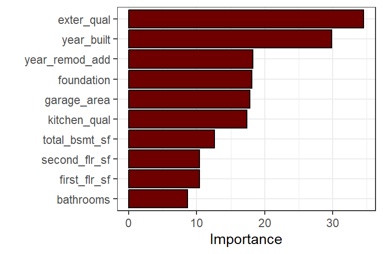

```r
# View Variable Importance Graph
final_house_rf %>%
  extract_fit_parsnip() %>%
  vip(aesthetics = list(fill = "#6e0000", col = "black"))
```

```r
# Create an view confusion matrix
pred_house_rf <- final_house_rf %>%
                    augment(house_test)
pred_house_rf %>%
  conf_mat(truth=overall_qual,estimate=.pred_class)
```

```
          Truth
Prediction High Low
      High   94  10
      Low    27  97
```

```r
curr_metrics <- pred_house_rf %>%
                    my_metrics(truth=overall_qual, estimate=.pred_class)

house_results <- tibble(model = 'Random Forest Model - Tuned',
                  Accuracy = curr_metrics[[1,3]],
                  Sensitivity = curr_metrics[[2,3]],
                  Specificity = curr_metrics[[3,3]])

house_results %>%
  kable(digits = 2)
```

| model | Accuracy | Sensitivity | Specificity |
| --- | --- | --- | --- |
| Random Forest Model - Tuned | 0.84 | 0.78 | 0.91 |

```r
ROC_threshold <- function(pred_data,truth,probs) {

  roc_curve_tbl <- pred_data %>%
                    roc_curve(truth = {{truth}}, {{probs}})
  auc = pred_data %>%
              roc_auc(truth = {{truth}}, {{probs}}) %>%
              pull(.estimate)
  best_row = which.max(roc_curve_tbl$specificity + roc_curve_tbl$sensitivity)
  print(paste("Best Cutoff:", round(roc_curve_tbl[best_row,'.threshold'],4),
              "Sensitivity:", round(roc_curve_tbl[best_row,'sensitivity'],4),
              "Specificity:", round(roc_curve_tbl[best_row,'specificity'],4),
              "AUC for Model:", round(auc,4)))
}

ROC_threshold(pred_house_rf, 'overall_qual', '.pred_High')
```

[output not shown]

```r
pred_house_rf_revised <- pred_house_rf %>%
  mutate(.pred_Class_1 = as.factor(ifelse(.pred_High<=0.4037 ,"Low","High")))

pred_house_rf_revised %>%
  conf_mat(truth = overall_qual, estimate = .pred_Class_1)
```

```
          Truth
Prediction High Low
      High  101  12
      Low    20  95
```

```r
curr_metrics1 <- pred_house_rf_revised %>%
                    my_metrics(truth = overall_qual, estimate=.pred_Class_1)

house_results1 <- tibble(model = 'Random Forest Model (Revised Cutoff = 0.4037)',
                                Accuracy = curr_metrics1[[1,3]],
                                Sensitivity = curr_metrics1[[2,3]],
                                Specificity = curr_metrics1[[3,3]])

house_results <- bind_rows(house_results,house_results1)

house_results %>%
  kable(digits = 4)
```

| model | Accuracy | Sensitivity | Specificity |
| --- | --- | --- | --- |
| Random Forest Model - Tuned | 0.8377 | 0.7769 | 0.9065 |
| Random Forest Model (Revised Cutoff = 0.4037) | 0.8596 | 0.8347 | 0.8879 |